# Introduction Python and the Jupyter Notebook

This file gives an introduction to Python and the Jupyter Notebook.

We assume that you have followed the [datacamp python course](https://campus.datacamp.com/courses/intro-to-python-for-data-science/chapter-1-python-basics?ex=1) so that you understand the python syntax.

As datacamp does not work with the notebook, this is new to you. The main thing to remember is: *shift-enter* evaluates a cell. A markdown-cell will be typeset and a python-cell will be evaluated if you press *shift-enter*.

## Learning Python

If --in addition to datacamp-- you would like to have more python resources, take a look at:

- http://quant-econ.net/py/learning_python.html gives a great introduction
- [Python for infomatics](http://www.pythonlearn.com/book.php) is a nice book; you can download it as ibook on your ipad/iphone and then it includes weblecturs
- if you are interested, you can check out http://www.pyladies.com/about/
- or just google on "python tutorial" and pick one that you like

## Markdown

A big advantage of the ipython notebook is that you can typeset equations to explain what you are doing. You type in a cell, but change the dropdown menu at the top of this page from "Code" to "Markdown".

There are numerous introductions to markdown on the web. See, for instance, [this on](http://daringfireball.net/projects/markdown/basics) on the basics. Google "markdown tutorial" and choose your favourite one.

To type equations in markdown, use [latex](http://www.latex-project.org). Double click on this cell in the notebook to see how you create equations. Symbols can be put between dollar signs, like $x$, $\alpha$, $y^2$ etc.

For an equation, type $$ \bar x = \sum_{i=1}^n x_i $$

There are lots of latex tutorials on the web, but mostly you can google what you want; like "latex phi" if you want to know how to type $\phi$. But also "latex empty set", "latex summation", "latex integral" etc. Together with copying what I do, this will do for the assignments. There is no need to learn latex.

## Some first code

We start with typing some code. You can execute the code (and change it) in the notebook (but not in the html file).

First, Python is a great calculator

```python
1+1
```

```
2
```

Now something a bit bigger:

```python
10**20
```

```
100000000000000000000L
```

As you note, in Python $10^{20}$ is written with ** not with ^.

We can define a variable $x$

```python
x = 10
```

```python
x+2
```

```
12
```

There are lists, tuples, dictionaries etc. From datacamp, you know what these different data types are and how they work.

Let's make a graph using [matplotlib](http://matplotlib.org). Also look at the [gallery](http://matplotlib.org/gallery.html) if you want to know how to do things.

First, we need to import this library:

```python
import matplotlib.pyplot as plt
%matplotlib inline
```

The first line says that we import matplotlib as "plt". Hence statements referring to this start with "plt", as you will see in a second. The second statement makes sure that we can see the graphs in the notebook as we make them.

Let's define a function that we all know, so that we understand what we are drawing.

```python
def my_first_function(x):
    return x**2
```

```python
my_first_function(4)
```

```
16
```

Well, that works. Note that when you type "my_" you can press the "tab" key to get auto-completion. Saves a bit of time when typing; and you cannot accidently type the wrong name which leads to an error lateron.

Before we can plot this function, we define for which values of $x$ we want to view this function. This is most easily done with the arange statement from scipy:

```python
from scipy import arange

range_x = arange(-2.0,2.1,0.1)
print range_x
```

```
[ -2.00000000e+00  -1.90000000e+00  -1.80000000e+00  -1.70000000e+00
  -1.60000000e+00  -1.50000000e+00  -1.40000000e+00  -1.30000000e+00
  -1.20000000e+00  -1.10000000e+00  -1.00000000e+00  -9.00000000e-01
  -8.00000000e-01  -7.00000000e-01  -6.00000000e-01  -5.00000000e-01
  -4.00000000e-01  -3.00000000e-01  -2.00000000e-01  -1.00000000e-01
   1.77635684e-15   1.00000000e-01   2.00000000e-01   3.00000000e-01
   4.00000000e-01   5.00000000e-01   6.00000000e-01   7.00000000e-01
   8.00000000e-01   9.00000000e-01   1.00000000e+00   1.10000000e+00
   1.20000000e+00   1.30000000e+00   1.40000000e+00   1.50000000e+00
   1.60000000e+00   1.70000000e+00   1.80000000e+00   1.90000000e+00
   2.00000000e+00]
```

Hence, "arange" creates an array starting at $-2.0$ going up to --but not including-- $2.1$ with steps $0.1$. Note the scientific notation with $e-01$. Finally, we are doing numerical stuff here, so $0$ looks "a bit odd".

Now we create a range of $y$-values that we want to draw. See how elegantly you define this new list of numbers:

```python
range_y = [my_first_function(x) for x in range_x]
print range_y
```

[output not shown]

As we are working numerically here, some numbers look a bit strange. But when we plot it later on, it will look familiar again. If you want to look at one element in this list, type

```python
range_y[0]
```

```
4.0
```

Note that Python starts counting at $0$. That also means that:

```python
range_y[41]
```

```
---------------------------------------------------------------------------
IndexError                                Traceback (most recent call last)
<ipython-input-11-366258d81fe1> in <module>()
----> 1 range_y[41]

IndexError: list index out of range
```

If you get an error like this, simply google "python list index out of range": you are not the first to encounter this problem...

Lists have other properties that you may not expect. For instance, although they may look like vectors to you, they are not:

```python
[5,6,7]-[1,1,1]
```

```
---------------------------------------------------------------------------
TypeError                                 Traceback (most recent call last)
<ipython-input-12-1683f32e17a9> in <module>()
----> 1 [5,6,7]-[1,1,1]

TypeError: unsupported operand type(s) for -: 'list' and 'list'
```

Hence you get an error. There are a number of solutions to this. Again google something like "python subtract lists" to see what other people have tried. Note that whereas I thought of $[5,6,7]-[1,1,1]$ as a vector operation, others see it as a set operation. What is the difference?

In order to work with lists as vectors, I tend to use

```python
from numpy import array
print array([5,6,7])-array([1,1,1])
```

```
[4 5 6]
```

Back to our graph, here is how you plot and save it:

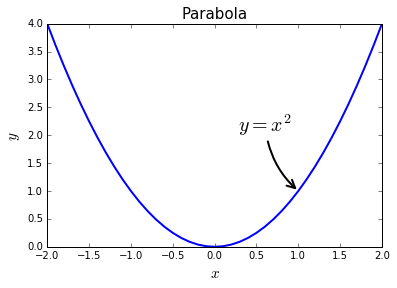

```python
plt.clf() # starts a new graph
plt.plot(range_x, range_y,'-', color = 'b', linewidth = 2) # play around with colors like 'r', or styles like '--'
plt.title("Parabola",fontsize = 15)
plt.xlabel("$x$",fontsize = 15)
plt.ylabel("$y$",fontsize = 15)
plt.xlim(-2.0,2.0)
plt.ylim(0.0,4.0)
plt.annotate('$y=x^2$', xy=(1.0,my_first_function(1.0)),  xycoords='data',
              xytext=(-60, 60), textcoords='offset points', size = 20,
              arrowprops=dict(arrowstyle="->", linewidth = 2,
                              connectionstyle="arc3,rad=.2"),
              )

plt.savefig('my_first_graph.png')
```